# Effect of Income Levels on Vaccination Rates of COVID-19

Yinan Cheng 920232770

Mar 12, 2022

# Abstract

In this project, we figure out the effect of income levels on vaccination rates. We conduct descriptive analysis to obtain basic information of the vaccination rates for different income levels and different regions. We employ a two-way ANOVA model and a linear mixed-effects model to further explore the relation between vaccination rates and income levels. Our results show that in general, the higher income levels, the higher vaccination rates. Vaccination inequality and health inequality exist among countries of different income levels. Countries of low income have the lowest vaccination rates overall.

# 1 Introduction

COVID-19 pandemic has dramatically affected our lives for more than two years. Millions of people died because of COVID-19 virus infection. Fortunately, a lot of pharmaceutical companies have developed COVID-19 vaccines which can relieve symptoms of COVID-19. However, not everyone is vaccinated against COVID-19. Some countries have high vaccination rates while others’ vaccination rates are very low. There is still a great challenge in resolving the pandemic due to inequity in the access to vaccines. In this project, we focus on the effect of income levels which is one of possible factors affecting vaccination rates. The result of our project will help to find out countries of which income level need additional aid to improve vaccination, which would promote health equity in our world.

### 1.1 Main goal

In this project, our question of interest is the relation between COVID-19 vaccination rates and income levels of countries. Our hypothesis is that the lower the income levels, the lower the vaccination rates. To test our hypothesis, we analyze data in following steps.

- Conduct descriptive analysis to obtain basic information of income levels and information of COVID-19 in different countries.
- Employ a two-way ANOVA model using cumulative vaccination rates of each country to find out the general relation between income levels and vaccination rates
- Construct a linear mixed-effects model to further explore the relation between income levels and monthly vaccination rates.

### 1.2 Data description and model setup

In order to conduct data analysis, we use data from [World Health Organization (WHO)](https://covid19.who.int/info) and data from [Our World in Data](https://github.com/owid/covid-19-data/tree/master/public/data). Income levels of each country is determined by the [World Bank](https://datatopics.worldbank.org/world-development-indicators/the-world-by-income-and-region.html), and region division is determined by WHO.

- Income levels: low income, lower-middle income, upper-middle income and high income
- Regions: America, Africa, Eastern Mediterranean, Western Pacific, South-East Asia and Europe

Vaccination rate of one country is the average number of people who get fully vaccinated among 100 people. More specifically, cumulative vaccination rate of one country refers to the vaccination rate so far. It equals to $\frac{n}{N} \times 100$, where $n$ is the cumulative number of people who get fully vaccinated so far and $N$ is the population number of the country. Monthly vaccination rates refer to vaccination rates for each month. It is equal to $\frac{n_m}{N} \times 100$, where $n_m$ is the number of people who get fully vaccinated in month $m$ and not get fully vaccinated before month $m$.

For the two-way ANOVA model, we use the data whose observations are countries. For linear mixed-effects model, we use [longitudinal data](https://en.wikipedia.org/wiki/Panel_data) whose observations are countries for each month, and we consider countries of each month as the random effect part.

1. Two-way ANOVA model
   - Response: cumulative vaccination rates
   - Factor: income level, region
2. Linear mixed-effects model
   - Response: monthly vaccination rates
   - Factor: income level, region, country, month

# 2 Background

### 2.1 Source of data

In this project, data of cumulative vaccination rates and regions come from WHO dataset, monthly vaccination rates are calculated using data from Our World in Data, and information of income levels is provided by the World Bank.

For datasets from WHO and Our World in Data, the target population is the population of the whole world. They contain all data reported by each country, which is their sampling mechanism. WHO provides data of basic information of COVID-19 for 228 countries, including regions, death rates, case rates, etc. Countries are divided into different regions according to their geographic locations. World in Data provides daily vaccination information of each country, and we calculate monthly vaccination rates based on this dataset via taking the sum of numbers of fully vaccinated people in each day of month m as the number of fully vaccinated people in month m, which is $n_m$. The following figure shows variation of cumulative vaccination rates for the geographic location of each country. Overall, the vaccination rates for countries in Africa are obviously lower than countries in other continents.

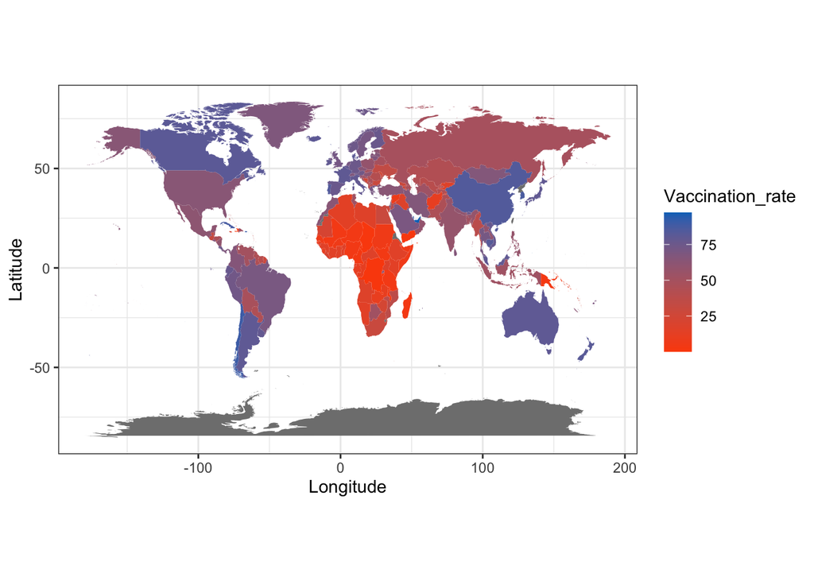

The World Bank classifies countries into different incomes levels according to [gross national income (GNI)](https://en.wikipedia.org/wiki/Gross_national_income) per capita data for each country, and there are four income levels: low income, lower-middle income, upper-middle income and high income. From the following figure, most high-income countries are distributed in North America, Europe and Oceania, most low-income countries are in Africa, and most upper-middle-income countries belong to Asia and South America.

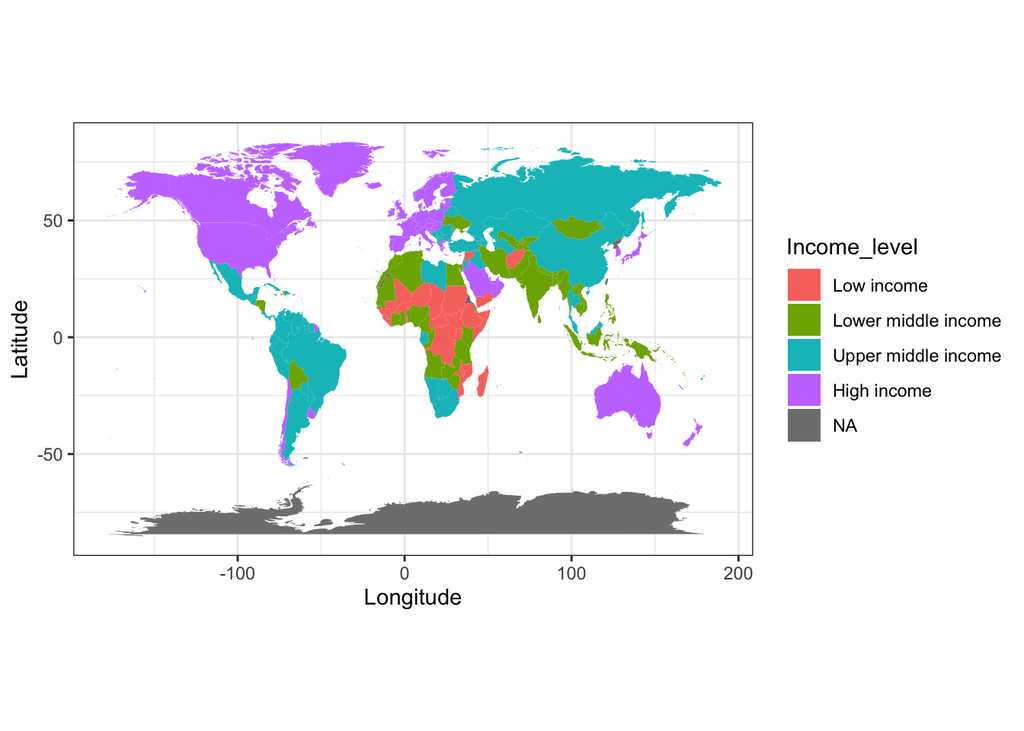

### 2.2 Previous research

Previous work indicates that there is a relationship between income levels and vaccination rates. Ramachandran, Ross and Miller (2021) examined authorization of COVID-19 vaccines and obtained the result that high-income countries have more doses to vaccinate than middle-income and low-income countries. Duan et al. (2021) analyzed the association between income disparity and vaccination rates and studied the mediating role of vaccination policy. They conducted a cross-sectional ecological research and found that upper-middle-income, lower-middle-income, and low-income countries have lower vaccination rates than high-income countries. Tuttle’s research (2021) compared vaccination rates for families with different incomes in the United States. The result showed that states with lower median incomes have lower vaccination rates generally.

# 3 Descriptive analysis

### 3.1 Summary statistics

The following table shows current situation of COVID-19. It includes mean cumulative vaccination rates (per 100 people), mean case rate (case numbers per 100000 people), mean death rate (death numbers per 100000 people) and mean mortality rate (death numbers per 100000 cases) for countries of different income levels. All of them are cumulative rates or numbers so far. From the table, we can see that cumulative vaccination rate is the highest for high-income countries and the lowest for low-income countries. Case rate, death rate and mortality rate are also different for different income levels, which can be future research topics.

| Income_Level | Vaccination_Rate | Case_Rate | Death_Rate | Mortality_Rate |
| --- | --- | --- | --- | --- |
| Low income | 12.34 | 304.25 | 6.62 | 2,177.03 |
| Lower middle income | 37.79 | 2,986.43 | 42.23 | 1,414.05 |
| Upper middle income | 48.96 | 10,947.61 | 168.01 | 1,534.67 |
| High income | 72.70 | 24,240.98 | 148.85 | 614.04 |

We also obtain summary statistics of cumulative vaccination rates for different income levels. In the following table, we can see that for each statistic, high income level has the highest vaccination rate and low income level has the lowest vaccination rate.

[output not shown]

### 3.2 Visualization

We first explore the relation between income levels and regions of each country which is shown in the following figure. We can see that most low-income countries are in Africa and most high-income countries are in Europe and America. Because of this relation, we use both of income levels and regions to fit the model.

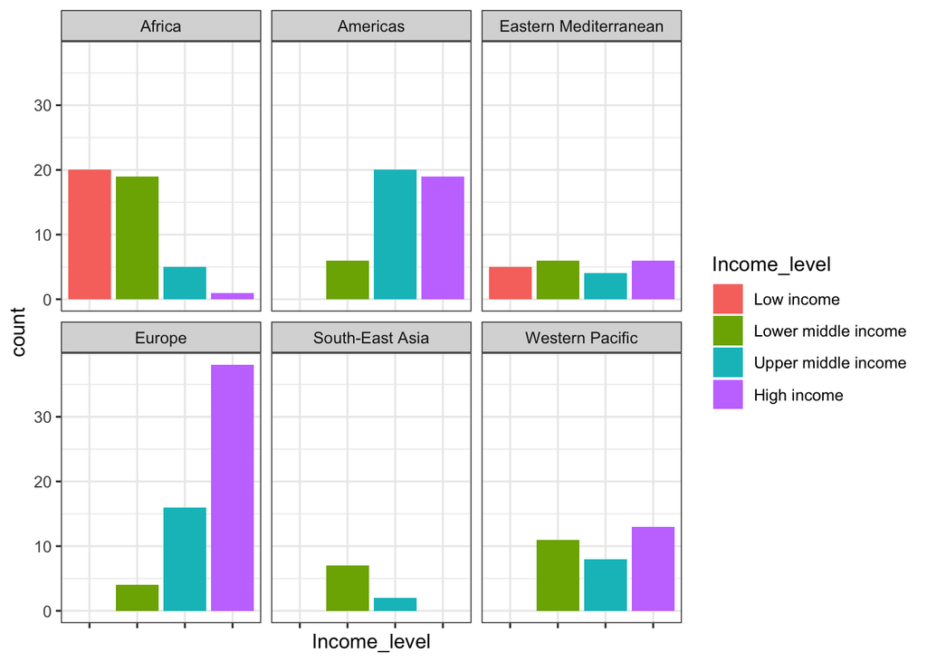

Then we investigate the effect of income levels and regions on cumulative vaccination rates respectively. We can see that overall the higher income level, the higher cumulative vaccination rates. The median rate for high-income countries is about 75 per 100 people while the median rate for low-income countries is less than 10 per 100 people. The second boxplot indicates that Africa has the lowest cumulative vaccination rate in general.

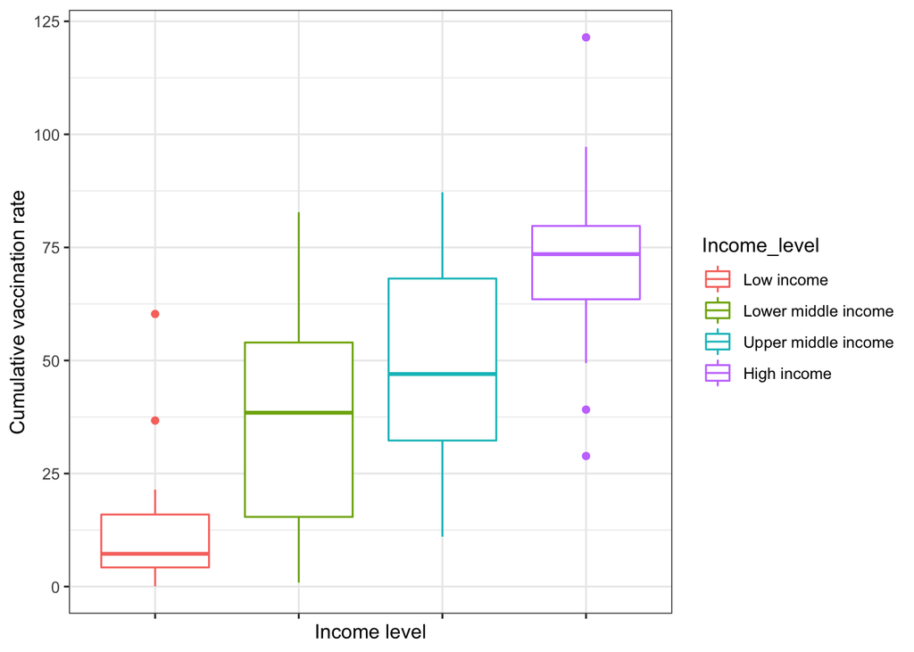

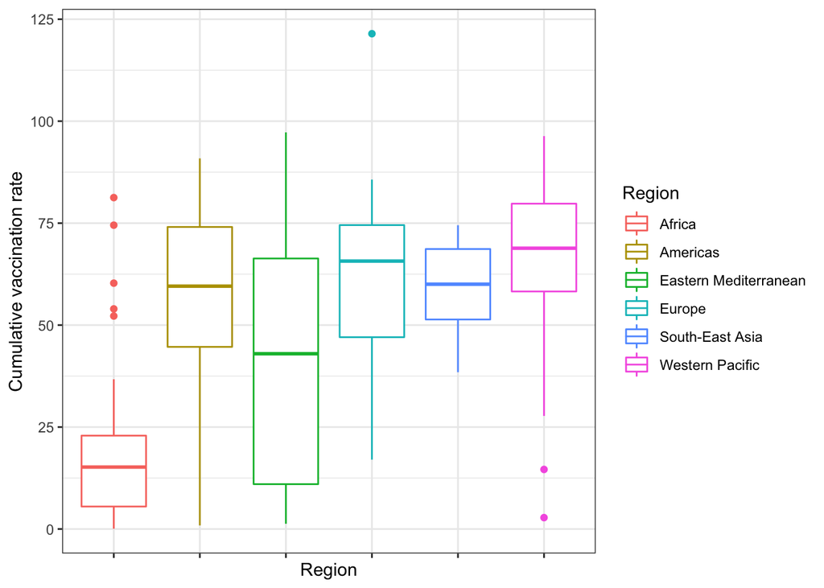

In order to study the effect of income levels on monthly vaccination rates, we sketch the line chart of monthly vaccination rates of each income level over time. The following figure indicates two points. First, in general, the higher income level, the higher monthly vaccination rates in the first half part (before 2021 July) in the figure on average. Second, we can see that each income level has a peak monthly vaccination rate, and the higher income level, the earlier the peak came up.

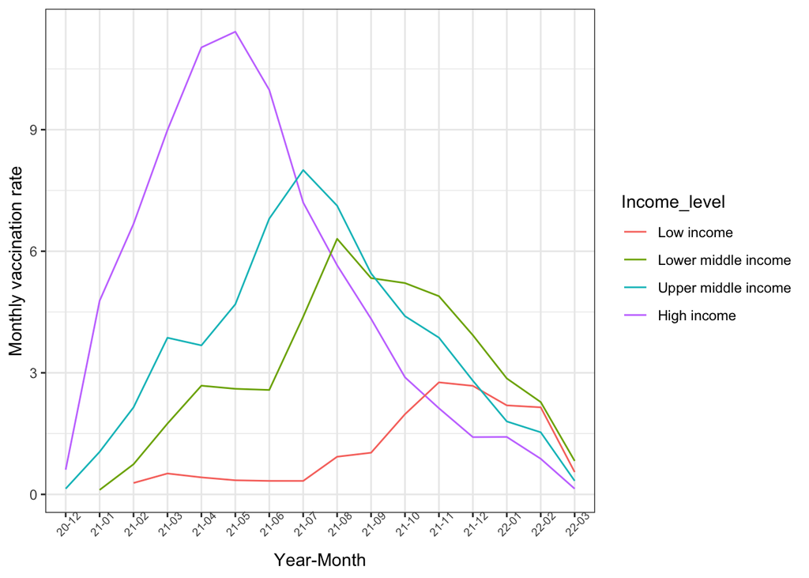

# 4 Inferential analysis

### 4.1 Two-way ANOVA

We employ a two-way ANOVA model to see whether income levels and regions have an effect on cumulative vaccination rates. We first need to determine whether there are interaction terms included in the model. We conduct F-test of the full model and the reduced model, and the result indicates that there is significant interaction between regions and income levels under 0.05 significance level. Therefore, we can establish a two-way ANOVA model including interaction terms. However, one concern is that the sample size is small in each cell of the interaction, which might lead to unreliable results. To deal with this problem, we fit another two-way ANOVA model without interaction in Appendix A to see whether results of following analysis change a lot.

Our two-way ANOVA model has the following form:

$$Y_{ijk} = \mu_{..} + \alpha_{i} + \beta_{j} + {(\alpha\beta)}_{ij} + \epsilon_{ijk}$$
.

- $Y_{ijk}$ is the response: cumulative vaccination rate.
- $\mu_{..}$ is the population mean.
- $\alpha_{i}$ is corresponding to income levels for $i = 1,...,4$.
- $\beta_{j}$ is corresponding to regions for $j = 1,...,6$.
- ${(\alpha\beta)}_{ij}$ is is the interaction term.
- $\epsilon_{ijk}$ are $i_.i_.d_.$ $N(0,\sigma^2)$, $k = 1,...,n_{ij}$.

Equivalently, we can express the model in another form with $N_T$ observations and $p$ fixed effects:
$$Y = {X\beta} + {\varepsilon}$$

- $Y$ is an $N_T \times 1$ vector of cumulative vaccination rates.
- $X$ is an $N_T \times p$ matrix of independent variables.
- $\beta$ is a $p \times 1$ column of fixed effects coefficients.
- $\varepsilon$ is the error term with multivariate Normal distribution $N(0, \sigma^2 I)$.

We also need to consider assumptions of the model, which are normality, equal variance, independence and identical distribution assumptions for error terms.

We take “low income” as the reference in the model. For statistical inference, we find that p-values of all effects are smaller than 0.05, so our model shows factors have an significant effect on the response. Especially, the p-values for coefficients of income levels show that income levels are effective on the cumulative vaccination rates.

| Income_level | Estimated_coefficient | P_value |
| --- | --- | --- |
| Lower middle | 6.140 | 0.023681 |
| Upper middle | 23.206 | 0.003458 |
| High | 67.935 | 0.000037 |

We conduct F-test to determine whether there is any difference in cumulative vaccination rates among all income levels. The p-value of F-test is much smaller than 0.05, which indicates that we can reject the null hypothesis under 0.05 significance level. So, cumulative vaccination rates are different among countries of different income levels.

$$H_0: \alpha_1 = \alpha_2 = \alpha_3 = \alpha_4 \ \ vs. \ \ H_a: Not \ all \ \alpha_i \ are \ the \ same$$

We employ Tukey’s method to figure out 95% family-wise confidence intervals for difference of vaccination rates for each two income levels in the following figure.

In the following figure:

- L: low income
- LM: lower middle income
- UM: upper middle income
- H: high income

The following figure presents the difference of mean cumulative vaccination rates of different income levels. For instance, the first confidence interval (H-L: High income level minus low income level) is the confidence interval of the vaccination rate difference between high income level and low income level. The upper three confidence intervals (H-L, LM-L, UM-L) show the differences of mean vaccination rates between countries of low income and other three income levels respectively. All of them are in the right of the zero line, so low-income countries have the lowest vaccination rates. The forth and fifth confidence intervals (LM-H, UM-H) as well as the first interval (H-L) indicate that high-income countries have the highest vaccination rates overall. The sixth interval (UM-LM) shows that the mean vaccination rate of upper-middle-income countries is higher than that of lower-middle-income countries. Therefore, we can obtain the rank of mean vaccination rates for different income levels: high income level > upper-middle income level > lower-middle income level > low income level. This figure indicates the inequality of vaccination for countries of different income levels.

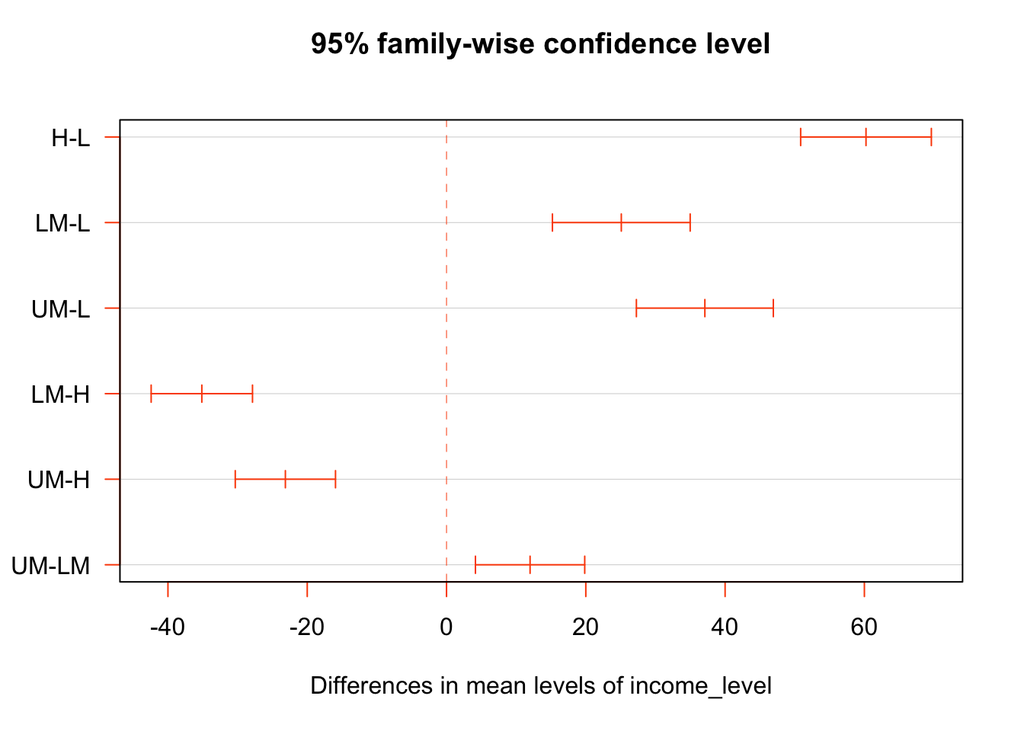

To deal with the problem that the sample size is small in each cell of the interaction which might lead to unreliable results, we also fit a model without the interaction term. Results are shown in Appendix A. From the table and the figure of confidence intervals in Appendix A, we can see that we obtain similar results to the model with interaction term. Therefore, it is convinced that low-income countries have the smallest cumulative vaccination rates overall.

### 4.2 Linear mixed-effects model

In this section, we fit a linear mixed-effects model because month is an important variable for monthly vaccination rates. In this model, we use four predictors: income level, region, country and month. We put countries for each month in the random effect part and other predictors in the fixed effect part.

We can express the model in the form with $N_T$ observations and $p$ fixed effects and $q$ random effects:
$$Y = {X\beta} + {Z\nu} + {\varepsilon}$$

- $Y$ is an $N_T \times 1$ vector of monthly vaccination rates.
- $X$ is an $N_T \times p$ matrix of predictors with fixed effects.
- $\beta$ is a $p \times 1$ vector of fixed effects coefficients.
- $Z$ is an $N_T \times q$ matrix of predictors with random effects.
- $\nu$ is a $q \times 1$ vector of random effects coefficients.
- $\varepsilon$ is the error term with multivariate Normal distribution $N(0, \sigma^2 I)$.

Monthly vaccination rate is right-skewed, so we first conduct Box-Cox transformation of the response variable. The figures show that the response is distributed normally after transformation.

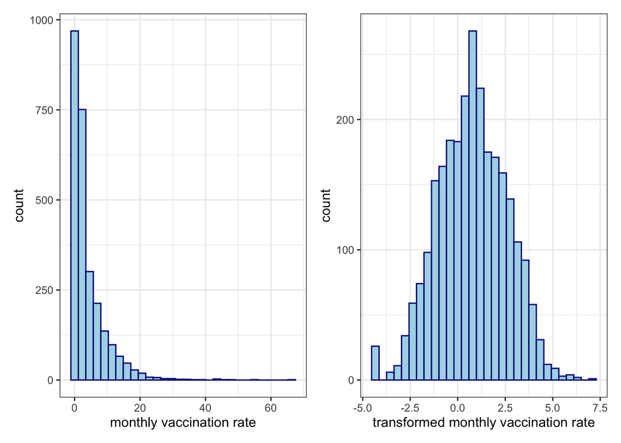

We use the package “[lme4](https://cran.r-project.org/web/packages/lme4/vignettes/lmer.pdf)” to fit the model and conduct statistical inference. We still take low income as the baseline of the income levels to fit the model. The p-values indicate income levels are significantly effective on the monthly vaccination rates.

| Income_level | Estimated_coefficient | P_value |
| --- | --- | --- |
| Lower middle | 0.625 | 0.00166 |
| Upper middle | 1.213 | 0.00007 |
| High | 1.773 | 0.00328 |

The linear mixed-effects model in the package use [Wald interval](https://towardsdatascience.com/five-confidence-intervals-for-proportions-that-you-should-know-about-7ff5484c024f) to figure out 95% confidence intervals. The following table shows three 95% confidence intervals of the difference between countries of low income and other three types of income levels. We can see that all of these three intervals exclude zero and are larger than zero. Hence, when we consider the monthly vaccination rates as the response variable, low-income countries still have the lowest vaccination rates overall.

| Difference of income levels | 95% Confidence interval |
| --- | --- |
| Lower middle - Low | [0.251, 0.991] |
| Upper middle - Low | [0.646, 1.775] |
| High - Low | [0.652, 2.885] |

# 5 Sensitivity analysis

### 5.1 Model diagnostics for two-way ANOVA

The residual vs. fitted value plot presents that residuals are distributed around the zero line homogeneously. The Q-Q plot shows that normality assumption is satisfied though points in the left side and right side are a little deviated from the line.

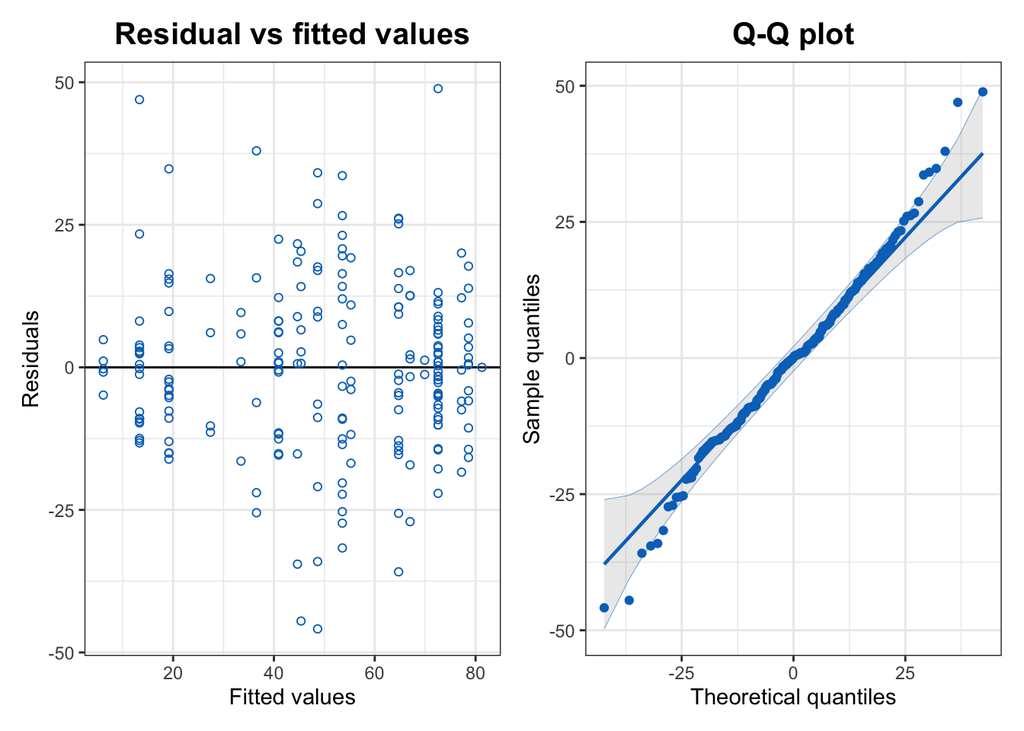

We employ Levene’s test, [Shapiro–Wilk test](https://en.wikipedia.org/wiki/Shapiro–Wilk_test) and [Wald–Wolfowitz runs test](https://en.wikipedia.org/wiki/Wald–Wolfowitz_runs_test) to test equal variance assumption, normality assumption and independence assumption, respectively. The null hypothesis for Shapiro–Wilk test is that the distribution is normal distribution, and the null hypothesis for Wald–Wolfowitz runs test is that subjects are independent (subjects are residuals here).The result shows that the equal variance assumption is not satisfied, but the normality assumption and the independence assumption are valid under 0.05 significance level. Besides, Bonferroni outlier test shows no outliers are identified.

| Test | Assumption | P_value |
| --- | --- | --- |
| Levene's test | Equal variance | 0.00311 |
| Shapiro–Wilk test | Normal distribution | 0.14650 |
| Wald–Wolfowitz runs test | Independence | 0.94390 |

### 5.2 Model diagnostics for linear mixed-effects model

The residual vs. fitted value plot shows residuals are distributed around the zero line homogeneously. The Q-Q plot shows no obvious violation of normality assumption even though the points in the two sides deviate from the line a little. Bonferroni outlier test is also used and the result is no outliers because all p-values for standardized residuals are larger than 0.05.

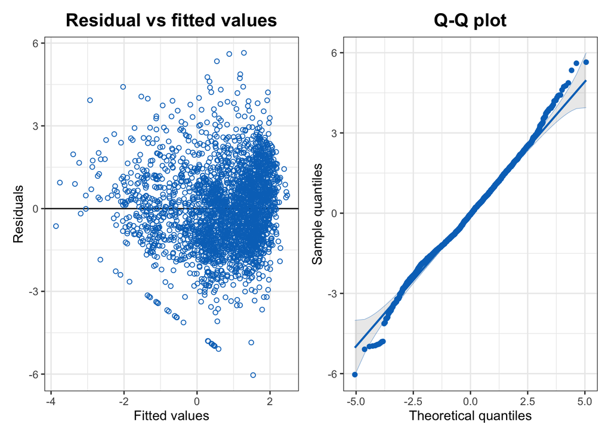

# 6 Conclusion and discussion

In this project, we find the association between vaccination rates and income levels. For both of the two-way ANOVA model and the linear mixed-effets model, low-income countries have the lowest cumulative and monthly vaccination rates in general and high-income countries have the highest cumulative and monthly vaccination rates. In addition, more people in countries of higher income levels get fully vaccinated earlier overall. Vaccination inequality exists, and low-income countries might need more help to improve their vaccination rates.

In the diagnostics section, Q-Q plots and Shapiro–Wilk test indicate nortality assumptions are valid, Wald–Wolfowitz runs test shows independence assumption is satisfied, but Levene’s test indicates the equal variance assumption is not significantly satisfied under 0.05 significance level. However, Levene’s test also shows that the equal variance assumption is valid under 0.001 significance level. In further research, other tests for equal variance should be employed to see whether the assumption is satisfied.

We only explore the relation between income levels and vaccination rates. According to the summary statistics, the case rates, death rates and the mortality rates also seem different for different income levels, so for further research, the relation of income levels and case rates, death rates or mortality rates of COVID-19 should be studied, which would promote the health equality of the world.

# Reference

[1] Vaccination data. 2022. World Health Organization. https://covid19.who.int/who-data/vaccination-data.csv.

[2] Data on COVID-19. 2022. Our World in Data. https://covid.ourworldindata.org/data/owid-covid-data.csv.

[3] The world by income and region. 2020. https://datatopics.worldbank.org/world-development-indicators/the-world-by-income-and-region.html.

[4] Longitudinal data (panel data). https://en.wikipedia.org/wiki/Panel_data.

[5] Gross national income. https://en.wikipedia.org/wiki/Gross_national_income.

[6] Reshma Ramachandran, Joseph S. Ross, Jennifer E. Miller. 2021. Access to COVID-19 Vaccines in High-, Middle-, and Low-Income Countries Hosting Clinical Trials. JAMA Network, Global Health.

[7] Yuqi Duan, Junyi Shi, Zongbin Wang, Shuduo Zhou, Yinzi Jin, Zhi-Jie Zheng. 2021. Disparities in COVID-19 Vaccination among Low-, Middle-, and High-Income Countries: The Mediating Role of Vaccination Policy. National Center for Biotechnology information. Vaccines (Basel). 2021 Aug 14;9(8):905. doi: 10.3390/vaccines9080905. PMID: 34452030; PMCID: PMC8402650.

[8] Brad Tuttle. 2021. Why States With the Lowest Median Incomes Have the Lowest Vaccination Rates. Money Investigation.

[9] Douglas Bates, Martin Mächler, Benjamin M. Bolke,r Steven C. Walker. 2015. Fitting Linear Mixed-Effects Models Using lme4. https://cran.r-project.org/web/packages/lme4/vignettes/lmer.pdf.

[10] Dennis Robert. 2020. Five Confidence Intervals for Proportions That You Should Know About. https://towardsdatascience.com/five-confidence-intervals-for-proportions-that-you-should-know-about-7ff5484c024f

[11] Shapiro–Wilk test. https://en.wikipedia.org/wiki/Shapiro–Wilk_test.

[12] Wald–Wolfowitz runs test. https://en.wikipedia.org/wiki/Wald–Wolfowitz_runs_test.

# Acknowledgement

We would like to thank our professor Shizhe Chen and teaching assistants Zitong Zhang and Zhikuan Quan for their guidance and advice. Also thanks Shuyu Guo, Kyung Jin Lee and Pablo Busch for their feedbacks and suggestions.

# Appendix

### Appendix A

We also fit a two-way ANOVA model without interaction term. The following table shows estimated coefficients with p-values for income levels. We still use “low income” as the reference. The figure presents 95% confidence intervals which are similar to those for the model including the interaction term.

| Income_level | Estimated_coefficient | P_value |
| --- | --- | --- |
| Lower middle | 13.612 | 0.00304 |
| Upper middle | 24.084 | 3.6e-06 |
| High | 47.729 | < 2e-16 |

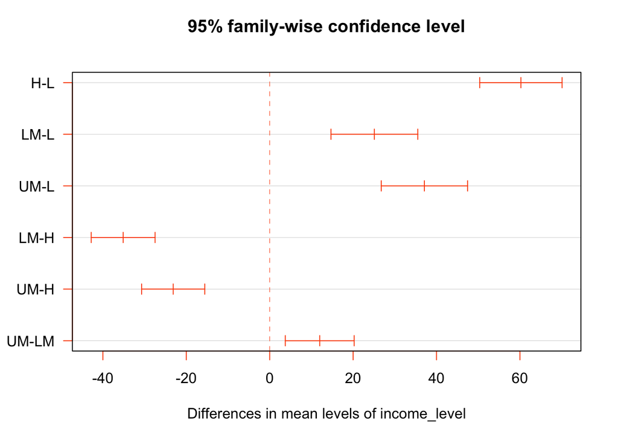

### Appendix B

Codes are uploaded in [GitHub](https://github.com/yinan-cheng/STA207-Project).